# 🚀 Shuttle Failure Analysis

Bhuvnesh Kochhar

# 1 📝 Introduction

This report analyzes the **ex2011** dataset (Sleuth3 library in R), which contains **24 observations** of space shuttle launch temperatures (in Fahrenheit) and information on O-ring failure (Yes/No) at those temperatures. The objective is to investigate the relationship between launch temperatures and the likelihood of O-ring failure, using **Logistic Regression (GLM)** .

# 2 🔍 Objectives

The aim of this report is:

- **a)** To determine if a relationship exists between the likelihood of O-ring failures and the temperature at launch time.
- **b)** To predict the probability of failure at **31°F**.

# 3 📊 Methodology

The **ex2011** dataset was imported from the **Sleuth3** library in R. The data was then modeled using a **Generalized Linear Model (GLM)** with a binomial family parameter, commonly, referred to as **Logistic Regression** to investigate the relationship between the probability of O-ring failure (Y-axis) and the launch temperature (X-axis).

# 4 🧮 Results

After fitting the GLM (log.temp), the analysis showed an **inverse relationship** between failure status and launch temperature. The temperature coefficient was **-0.17132**, which is statistically significant (**p-value: 0.04**). The resulting equation is:

> **log(Failure) = 10.87535 - 0.17132 * Temperature**

Using this model, the probability of failure at **31°F** was calculated to be **99.6%**.

# 5 💡 Discussion

The analysis demonstrates a **high likelihood of failure at 31°F (99.6%)**. Furthermore, the temperature coefficient indicates that the odds of O-ring failure **increase by 18.7% for every 1°F drop** in temperature, underlining the sensitivity of the O-rings to low temperatures.

**Limitations**:

1. Small sample size of only 24 observations.
2. As shown in Figure 1, the prediction at 31°F falls outside the range of fitted values, making extrapolation potentially unreliable.
3. The curvature suggests a **non-linear relationship**, indicating that the true failure range at lower temperatures may be more complex than this model captures.

# 6 📂 Appendix

## 6.1 📥 Import and Load Data

```r
library(Sleuth3)

data.temp <- ex2011
summary(data.temp)
```

```
##   Temperature    Failure
##  Min.   :53.00   No :17
##  1st Qu.:67.00   Yes: 7
##  Median :70.00
##  Mean   :69.92
##  3rd Qu.:75.25
##  Max.   :81.00
```

## 6.2 📈 Fitting the Generalized Linear Model (log.temp)

```r
log.temp<-glm(Failure~Temperature,data = data.temp,family = 'binomial')

summary(log.temp)
```

```
##
## Call:
## glm(formula = Failure ~ Temperature, family = "binomial", data = data.temp)
##
## Deviance Residuals:
##     Min       1Q   Median       3Q      Max
## -1.2125  -0.8253  -0.4706   0.5907   2.0512
##
## Coefficients:
##             Estimate Std. Error z value Pr(>|z|)
## (Intercept) 10.87535    5.70291   1.907   0.0565 .
## Temperature -0.17132    0.08344  -2.053   0.0400 *
## ---
## Signif. codes:  0 '***' 0.001 '**' 0.01 '*' 0.05 '.' 0.1 ' ' 1
##
## (Dispersion parameter for binomial family taken to be 1)
##
##     Null deviance: 28.975  on 23  degrees of freedom
## Residual deviance: 23.030  on 22  degrees of freedom
## AIC: 27.03
##
## Number of Fisher Scoring iterations: 4
```

## 6.3 🔄 Calculating Rate of Change (Rate_of_change)

```r
exp(-log.temp$coefficients)
```

```
##  (Intercept)  Temperature
## 0.0000189189 1.1868710813
```

```r
rate_of_change <- (exp(-log.temp$coefficients)[2] - 1) * 100
rate_of_change
```

```
## Temperature
##    18.68711
```

## 6.4 🔮 Probability of Failure at 31°F

```r
# Predict the probability of failure at 31°F
temp_31 <- 31
log_odds <- 10.87535 - (0.17132 * temp_31)
probability <- exp(log_odds) / (1 + exp(log_odds))
probability
```

```
## [1] 0.9961829
```

## 6.5 📊 Figure 1: Temperature vs. Probability of Failure

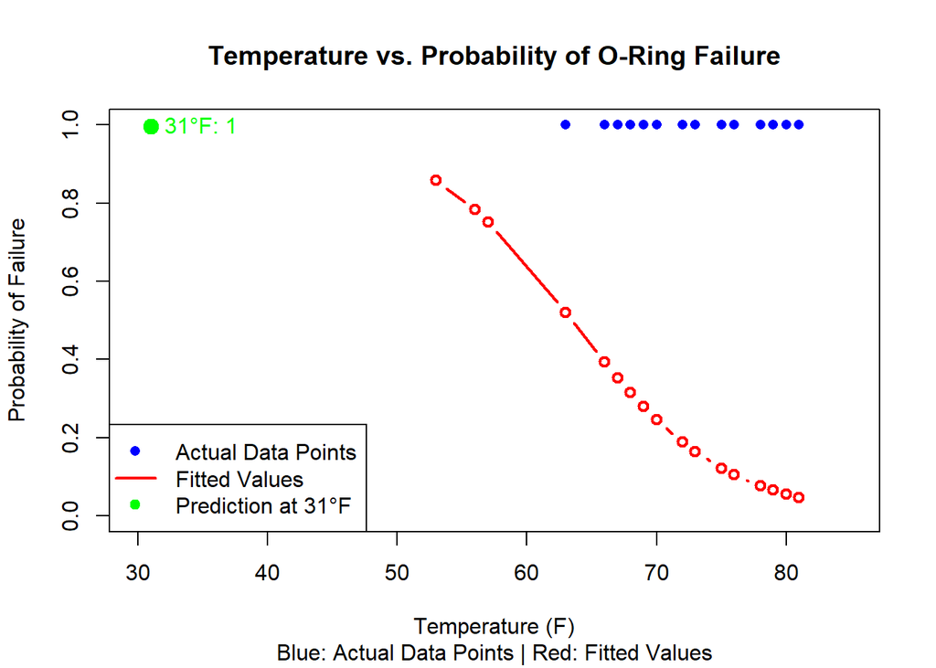

```r
# Plot for Temperature vs. Probability of O-Ring Failure
plot(data.temp$Temperature, data.temp$Failure,
     ylab = "Probability of Failure",
     xlab = "Temperature (F)",
     col = "blue",
     pch = 16,
     xlim = c(30, 85),
     ylim = c(0, 1),
     main = "Temperature vs. Probability of O-Ring Failure",
     sub = "Blue: Actual Data Points | Red: Fitted Values")


# Add fitted values curve
lines(data.temp$Temperature, fitted.values(log.temp),
      col = "red",
      lwd = 2,
      type = "b")

# Highlight the predicted value at 31°F
points(31, probability, col = "green", pch = 19, cex = 1.5)
text(31, probability, labels = paste0("31°F: ", round(probability, 2)), pos = 4, col = "green")

# Add a legend
legend("bottomleft",
       legend = c("Actual Data Points", "Fitted Values", "Prediction at 31°F"),
       col = c("blue", "red", "green"),
       pch = c(16, NA, 19),
       lty = c(NA, 1, NA),
       lwd = c(NA, 2, NA),
       bg = 'white')
```